# What is the True Normal Human Body Temperature?

#### Background

The mean normal body temperature was held to be 37$^{\circ}$C or 98.6$^{\circ}$F for more than 120 years since it was first conceptualized and reported by Carl Wunderlich in a famous 1868 book. But, is this value statistically correct?

### Exercises

In this exercise, you will analyze a dataset of human body temperatures and employ the concepts of hypothesis testing, confidence intervals, and statistical significance.

Answer the following questions **in this notebook below and submit to your Github account**.

1. Is the distribution of body temperatures normal?
   - Although this is not a requirement for the Central Limit Theorem to hold (read the introduction on Wikipedia's page about the CLT carefully: https://en.wikipedia.org/wiki/Central_limit_theorem), it gives us some peace of mind that the population may also be normally distributed if we assume that this sample is representative of the population.
   - Think about the way you're going to check for the normality of the distribution. Graphical methods are usually used first, but there are also other ways: https://en.wikipedia.org/wiki/Normality_test
2. Is the sample size large? Are the observations independent?
   - Remember that this is a condition for the Central Limit Theorem, and hence the statistical tests we are using, to apply.
3. Is the true population mean really 98.6 degrees F?
   - First, try a bootstrap hypothesis test.
   - Now, let's try frequentist statistical testing. Would you use a one-sample or two-sample test? Why?
   - In this situation, is it appropriate to use the $t$ or $z$ statistic?
   - Now try using the other test. How is the result be different? Why?
4. Draw a small sample of size 10 from the data and repeat both frequentist tests.
   - Which one is the correct one to use?
   - What do you notice? What does this tell you about the difference in application of the $t$ and $z$ statistic?
5. At what temperature should we consider someone's temperature to be "abnormal"?
   - As in the previous example, try calculating everything using the boostrap approach, as well as the frequentist approach.
   - Start by computing the margin of error and confidence interval. When calculating the confidence interval, keep in mind that you should use the appropriate formula for one draw, and not N draws.
6. Is there a significant difference between males and females in normal temperature?
   - What testing approach did you use and why?
   - Write a story with your conclusion in the context of the original problem.

You can include written notes in notebook cells using Markdown:

- In the control panel at the top, choose Cell > Cell Type > Markdown
- Markdown syntax: http://nestacms.com/docs/creating-content/markdown-cheat-sheet

#### Resources

- Information and data sources: http://www.amstat.org/publications/jse/datasets/normtemp.txt, http://www.amstat.org/publications/jse/jse_data_archive.htm
- Markdown syntax: http://nestacms.com/docs/creating-content/markdown-cheat-sheet

```python
import pandas as pd
import matplotlib.pyplot as plt
from scipy.stats import shapiro
import numpy as np

df = pd.read_csv('data/human_body_temperature.csv')
```

# Question 1 and 2

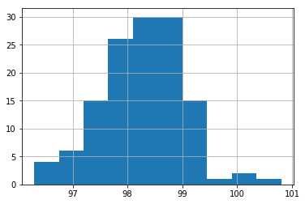

```python
df['temperature'].hist()
```

```python
stat, p = shapiro(df['temperature'])
print('Statistics=%.3f, p=%.3f' % (stat, p))
```

```
Statistics=0.987, p=0.233
```

```python
len(df.index)
```

```
130
```

Null Hypothesis is that it is normal

P-Value is greater than 0.05 so the hypothesis that distribution is normal cannot be rejected

Sample size of 130 is enough to run the statistical test for normality and since temperatures of different people do not depend on each other the observations are independent.

# Question 3

### Bootstrap test

```python
s_mean=np.mean(df['temperature'])
```

```python
s_mean
```

```
98.24923076923078
```

```python
df['shifted_temp']=df['temperature']-s_mean+98.6
```

```python
df
```

|  | temperature | gender | heart_rate | shifted_temp |
| --- | --- | --- | --- | --- |
| 0 | 99.3 | F | 68.0 | 99.650769 |
| 1 | 98.4 | F | 81.0 | 98.750769 |
| 2 | 97.8 | M | 73.0 | 98.150769 |
| 3 | 99.2 | F | 66.0 | 99.550769 |
| 4 | 98.0 | F | 73.0 | 98.350769 |
| 5 | 99.2 | M | 83.0 | 99.550769 |
| 6 | 98.0 | M | 71.0 | 98.350769 |
| 7 | 98.8 | M | 78.0 | 99.150769 |
| 8 | 98.4 | F | 84.0 | 98.750769 |
| 9 | 98.6 | F | 86.0 | 98.950769 |
| 10 | 98.8 | F | 89.0 | 99.150769 |
| 11 | 96.7 | F | 62.0 | 97.050769 |
| 12 | 98.2 | M | 72.0 | 98.550769 |
| 13 | 98.7 | F | 79.0 | 99.050769 |
| 14 | 97.8 | F | 77.0 | 98.150769 |
| 15 | 98.8 | F | 83.0 | 99.150769 |
| 16 | 98.3 | F | 79.0 | 98.650769 |
| 17 | 98.2 | M | 64.0 | 98.550769 |
| 18 | 97.2 | F | 68.0 | 97.550769 |
| 19 | 99.4 | M | 70.0 | 99.750769 |
| 20 | 98.3 | F | 78.0 | 98.650769 |
| 21 | 98.2 | M | 71.0 | 98.550769 |
| 22 | 98.6 | M | 70.0 | 98.950769 |
| 23 | 98.4 | M | 68.0 | 98.750769 |
| 24 | 97.8 | M | 65.0 | 98.150769 |
| 25 | 98.0 | F | 87.0 | 98.350769 |
| 26 | 97.8 | F | 62.0 | 98.150769 |
| 27 | 98.2 | F | 69.0 | 98.550769 |
| 28 | 98.4 | F | 73.0 | 98.750769 |
| 29 | 98.1 | M | 67.0 | 98.450769 |
| ... | ... | ... | ... | ... |
| 100 | 99.0 | M | 81.0 | 99.350769 |
| 101 | 98.5 | M | 68.0 | 98.850769 |
| 102 | 98.0 | F | 78.0 | 98.350769 |
| 103 | 99.4 | F | 77.0 | 99.750769 |
| 104 | 97.6 | M | 69.0 | 97.950769 |
| 105 | 96.7 | M | 71.0 | 97.050769 |
| 106 | 97.0 | M | 80.0 | 97.350769 |
| 107 | 98.6 | M | 66.0 | 98.950769 |
| 108 | 98.7 | F | 72.0 | 99.050769 |
| 109 | 97.3 | M | 69.0 | 97.650769 |
| 110 | 98.8 | F | 69.0 | 99.150769 |
| 111 | 98.0 | F | 89.0 | 98.350769 |
| 112 | 98.2 | F | 64.0 | 98.550769 |
| 113 | 99.1 | F | 74.0 | 99.450769 |
| 114 | 99.0 | M | 79.0 | 99.350769 |
| 115 | 98.0 | M | 64.0 | 98.350769 |
| 116 | 100.8 | F | 77.0 | 101.150769 |
| 117 | 97.8 | F | 71.0 | 98.150769 |
| 118 | 98.7 | M | 78.0 | 99.050769 |
| 119 | 98.4 | F | 74.0 | 98.750769 |
| 120 | 97.7 | F | 84.0 | 98.050769 |
| 121 | 97.9 | F | 68.0 | 98.250769 |
| 122 | 99.0 | F | 81.0 | 99.350769 |
| 123 | 97.2 | F | 66.0 | 97.550769 |
| 124 | 97.5 | M | 75.0 | 97.850769 |
| 125 | 96.3 | M | 70.0 | 96.650769 |
| 126 | 97.7 | M | 77.0 | 98.050769 |
| 127 | 98.2 | F | 73.0 | 98.550769 |
| 128 | 97.9 | M | 72.0 | 98.250769 |
| 129 | 98.7 | F | 59.0 | 99.050769 |

130 rows × 4 columns

```python
def sample_with_replacement(n, data):
    return np.random.choice(data, size=n)
```

```python
def calc_n_bootstrap_statistic(data, fn, n):
    stats=[]
    for i in range(n):
        sample_gen=sample_with_replacement(len(data),data)
        stat=fn(sample_gen)
        stats.append(stat)
    return stats
```

```python
means=np.array(calc_n_bootstrap_statistic(df['shifted_temp'], np.mean, 10000))
```

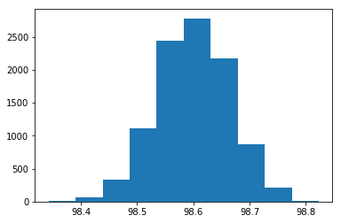

```python
plt.hist(means)
```

```python
len(means[means<=s_mean])/10000
```

```
0.0
```

#### According to this test the hypothesis that the true mean is 98.6 is rejected

## Frequentist tests

```python
from scipy import stats
```

```python
_,p=stats.ttest_1samp(df['temperature'],98.6)
```

```python
p
```

```
2.4106320415561276e-07
```

#### p-value low so reject null hypothesis that true mean is 98.6

```python
from statsmodels.stats import weightstats as stests
```

```python
_,p=stests.ztest(df['temperature'], value=98.6)
```

```python
p
```

```
4.9021570141012155e-08
```

#### p-value low so reject null hypothesis that true mean is 98.6

#### In this situation both t and z tests give the same result though z test seems to be better since its p-value is lower than that of t

# Question 4

```python
df_10=np.random.choice(df['temperature'],size=10)
```

```python
df_10
```

```
array([ 97.7,  98.2,  99.2,  98. ,  98.8,  98.7,  98.9,  98. ,  98.4,  98.8])
```

```python
_,p=stats.ttest_1samp(df_10,98.6)
```

```python
p
```

```
0.4169162402428418
```

```python
_,p=stests.ztest(df_10, value=98.6)
```

```python
p
```

```
0.39485423084115956
```

# Question 5

## Bootstrap method

```python
means=np.array(calc_n_bootstrap_statistic(df['temperature'], np.mean, 10000))
np.percentile(means,[2.5,97.5])
```

```
array([ 98.12536538,  98.37538462])
```

#### Temperature below 98.12 and above 98.37 should be considered abnormal according to bootstrap test on this data

## Frequentist method

```python
# z score for 95% confidence interval
z_score = 1.96
```

```python
margin=z_score*np.std(df['temperature'])/(len(df.index)**0.5)
```

```python
[s_mean-margin, s_mean+margin]
```

```
[98.12367980442819, 98.37478173403336]
```

#### This method also gives a range of temperatures similar to bootstrap method

# Question 6

## Using Frequentist method because number of data points is 65 which not that low

```python
df_males=df[df['gender']=='M']
```

```python
df_females=df[df['gender']=='F']
```

```python
len(df_males)
```

```
65
```

```python
len(df_females)
```

```
65
```

```python
_,p=stats.ttest_ind(df_males['temperature'],df_females['temperature'])
```

```python
p
```

```
0.023931883122395609
```

```python
_,p=stests.ztest(df_males['temperature'],df_females['temperature'])
```

```python
p
```

```
0.02228736076065755
```